# What Song Is that?

Vishesh S. Hiremath - vsh5db@virginia.edu

# Introduction

Have you ever tried to remember this song name, where you know what the song is about, and some parts of the lyrics, but can’t remember what song it is? Today we are going to learn a very easy way *(read: overly complicated but hey, we’re learning something new- way)* to be able to remember what song it is.

Today we are going to learn about a text analytics/NLP method called topic modeling. Topic modeling is primarily used for two reasons:

- Identifying what a particular document or corpus of documents is talking about.
- What are the top terms relating to a topic.

## Theory

We will need to understand two main theories related to topic modeling before we proceed.

### 1. LDA: Latent Dirichlet Allocation

LDA is a generative probabilistic model of a corpus. The basic idea is that the documents are represented as random mixtures over latent topics, where a topic is characterized by a distribution over words. Latent Dirichlet allocation (LDA), first introduced by Blei, Ng and Jordan in 2003, is one of the most popular methods in topic modeling. LDA represents topics by word probabilities. The words with highest probabilities in each topic usually give a good idea of what the topic is can word probabilities from LDA.

Various methods have been proposed to estimate LDA parameters, Gibbs sampling is one of the more commonly used method:

Gibbs sampling, is a Monte Carlo Markov-chain algorithm, powerful technique in statistical inference, and a method of generating a sample from a joint distribution when only conditional distributions of each variable can be efficiently computed. According to our knowledge, researchers have widely used this method for the LDA.

*Parts of the above text taken from: https://arxiv.org/pdf/1711.04305.pdf . Please go through the document for mathematical explanation of how LDA works.*

### 2. TFIDF: Term Frequency Inverse Document Frequency

TFIDF is another method (not exactly relating to topic modeling but commonly used together) which helps us get the top terms for a given document, when the document is a part of a bigger corpus. The main idea behind TFIDF is:

- The terms which describe the document appear a lot in the document.
- The terms which particularly describe **this** document appear less across all other documents.

Therefore, to find the top terms for a given document, we just need to find the term frequency for each document (common words having higher frequency value), and then multiply that with an inverse of document frequency(how frequently does that term appear across all documents?)

# Code

### Importing a database of lyrics

Lets first go ahead and import all the libraries that we are going to use at the top:

```r
library(tidyverse) # general utility & workflow functions
library(tidytext) # tidy implimentation of NLP methods
library(topicmodels) # for LDA topic modelling
library(tm) # general text mining functions, making document term matrixes
library(SnowballC) # for stemming
library(seewave) #For calculating KL Distance
```

Lets start by first creatinng a database of the lyrics. I found an open lyrics database of a select few songs here: https://github.com/Lyrics/lyrics Lets clone the github repository, and extract out the folder called **database**. The lyrics database is neatly organized with letter > artist > album > song structure. Once we have the directory structure ready, let’s go ahead and import the database:

```r
setwd("~/SYS6018/Final/")
filesInDir <- list.files(path = "./lyricsdb",  recursive= TRUE, full.names = TRUE)
filesdb <- data.frame(fullpath = filesInDir);
```

We can now process the filesdb data frame to get the artist, album, and song information in separate columns in the following way:

```r
processfilename = function(path, action = "song") {
  pathparts = strsplit(path, "/")
  if(action == "song") {
    return(toString(pathparts[[1]][6]))
  } else if(action == "album") {
    return(toString(pathparts[[1]][5]))
  } else if(action == "artist") {
    return(toString(pathparts[[1]][4]))
  }
  return(NA)
}
filesdb$song = sapply(as.character(filesdb$fullpath), processfilename, action="song")
filesdb$artist = sapply(as.character(filesdb$fullpath), processfilename, action="artist")
filesdb$album = sapply(as.character(filesdb$fullpath), processfilename, action="album")
```

Obviously, We also need to add a column for lyrics:

```r
getLyrics = function(filename) {
  lines = readLines(filename)
  lyrics = ""
  for(i in lines) {
    lyrics = paste(lyrics, i)
  }
  return(toString(lyrics[[1]]))
}
alllyrics = sapply(as.character(filesdb$fullpath), getLyrics)

filesdb$lyrics = alllyrics


head(filesdb)
```

|  | fullpath | song | artist | album | lyrics |
| --- | --- | --- | --- | --- | --- |
| 1 | ./lyricsdb/3/3 Doors Down/The Better Life/Kryptonite | Kryptonite | 3 Doors Down | The Better Life | I took a walk around the world to ease my troubled mind I left my body lying somewhere in the sands of time I watched the world float to the dark side of the moon I feel there's nothing I can do, yeah… |
| 2 | ./lyricsdb/A/A Day To Remember/Common Courtesy/Best Of Me | Best Of Me | A Day To Remember | Common Courtesy | What'd you expect from me? It's not my fault you'll never be happy Just 'cause you're right doesn't mean I'm wrong Our days were numbered and we knew it all along Can't you let things be? Now all that… |
| 3 | ./lyricsdb/A/A Day To Remember/Common Courtesy/City Of Ocala | City Of Ocala | A Day To Remember | Common Courtesy | Fuck ya! Remember way back when? They said this life was a dream Well it still is, and I never wanna wake Standing in my backyard at our old practice space Hard to hold back the tears from streaming d… |
| 4 | ./lyricsdb/A/A Day To Remember/Common Courtesy/Dead & Buried | Dead & Buried | A Day To Remember | Common Courtesy | Let me find the way that I can make do Without circumstance, without follow through A man in desperation can't trust a troubled mind I'm building an empire, say I'm wrong I don't mind if it's all agai… |
| 5 | ./lyricsdb/A/A Day To Remember/Common Courtesy/End Of Me | End Of Me | A Day To Remember | Common Courtesy | I took some time away for understanding Of what brought us here today Oh, you'll be the end of me I'm never happy like we were happy I'm never sad like we were sad Oh, you'll be the end of me You know… |
| 6 | ./lyricsdb/A/A Day To Remember/Common Courtesy/Good Things | Good Things | A Day To Remember | Common Courtesy | Hello, you don't seem like yourself At least from what I knew, you're somebody else Oh no, it's so much harder to take It took me four years to realize you're a fake But I won't lie, I'd forfeit all t… |

```r
lyricsdb = filesdb
```

With that our lyrics database is ready.

But we still need to clean the databse so we don’t face any problems later in the program:

```r
#cleaning the lyrics:
lyricsdb$lyrics = tm::removePunctuation(lyricsdb$lyrics, ucp=FALSE)
lyricsdb$lyrics = tm::removeNumbers(lyricsdb$lyrics, ucp=FALSE)
lyricsdb$lyrics = tm::stripWhitespace(lyricsdb$lyrics)
```

## LDA

Lets first look at generating the topics of LDA. This is just to learn how LDA works, but we will use TFIDF in the next step to match a description of the song with the lyrics.

top_terms_by_topic_LDA will take a column of text which has multiple documents in a database, and generate number_of_topics topics from those documents. It uses a default LDA method provided by the topicmodels package.

The following functions will help us get our topics for the documents that we pass:

```r
customStopWords <- c("the", "and", "http","github", "can", "use", "url", "Name", "Album", "Artist", "Common", "Courtesy")
top_terms_by_topic_LDA <- function(input_text, # should be a columm from a dataframe
                                   number_of_topics = 5) # number of topics (5 by default)
{


    # create a corpus (type of object expected by tm) and document term matrix
    CorpusObject <- tm::VCorpus(tm::VectorSource(input_text)) # make a corpus object


    DTM <- tm::DocumentTermMatrix(CorpusObject) # get the count of words/document

    # remove any empty rows in our document term matrix (if there are any
    # we'll get an error when we try to run our LDA): Technically not applicable for current project
    unique_indexes <- unique(DTM$i) # get the index of each unique value
    DTM <- DTM[unique_indexes,] # get a subset of only those indexes

    # preform LDA & get the words/topic in a tidy text format
    lda <- LDA(DTM, k = number_of_topics, control = list(seed = 1234))
    topics <- tidy(lda, matrix = "beta")

    custom_stop_words <- tibble(word = customStopWords)
    # remove stopwords
    tidyCleaned <- topics %>% # take our tidy dtm and...
      anti_join(stop_words, by = c("term" = "word")) %>% # remove English stopwords and...
      anti_join(custom_stop_words, by = c("term" = "word")) # remove my custom stopwords


    # get the top  terms for each topic
    top_terms <- tidyCleaned  %>% # take the topics data frame and..
      group_by(topic) %>% # treat each topic as a different group
      top_n(20, beta) %>% # get the top most informative words
      ungroup() %>% # ungroup
      arrange(topic, -beta) # arrange words in descending informativeness


      return(top_terms)
}

plot_top_terms <- function(top_terms) {
  # plot the top ten terms for each topic in order
  return(top_terms %>% # take the top terms
      mutate(term = reorder(term, beta)) %>% # sort terms by beta value
      ggplot(aes(term, beta, fill = factor(topic))) + # plot beta by theme
      geom_col(show.legend = FALSE) + # as a bar plot
      facet_wrap(~ topic, scales = "free") + # which each topic in a seperate plot
      labs(x = NULL, y = "Beta") + # no x label, change y label
      coord_flip() )# turn bars sideways
}
```

Let us now look at a common topics which our favourite aritsts write about:

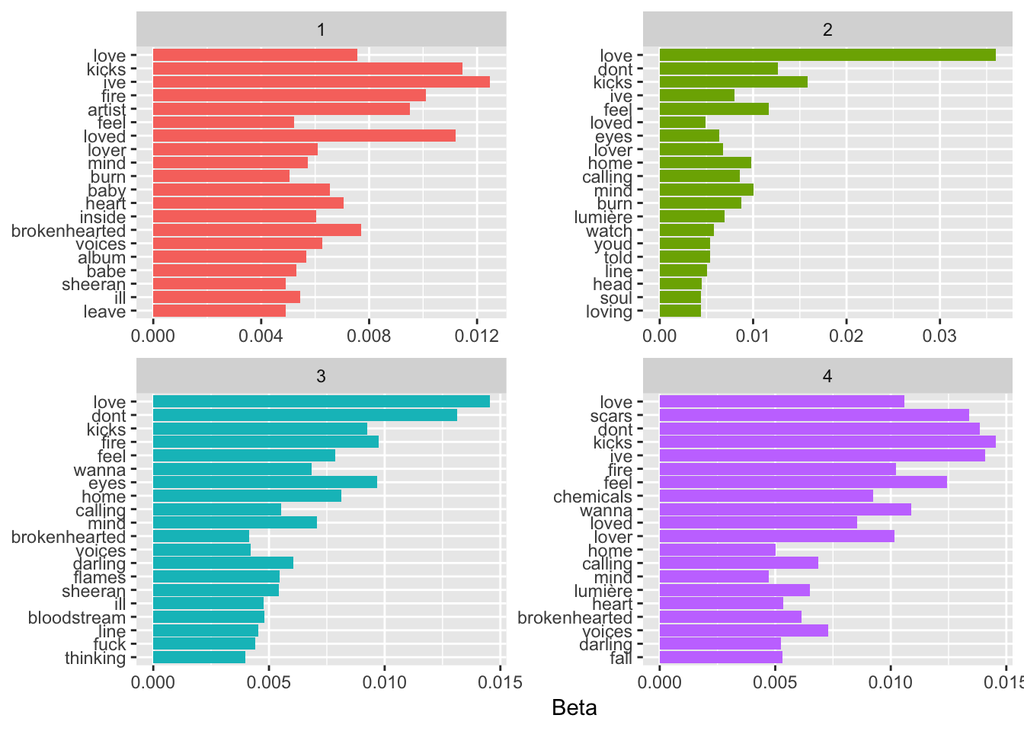

```r
#Checkinng for Ed Sheeran

edSheeranTopics <- top_terms_by_topic_LDA(lyricsdb %>% filter(artist == "Ed Sheeran") %>% select(lyrics), 4)
plot_top_terms(edSheeranTopics)
```

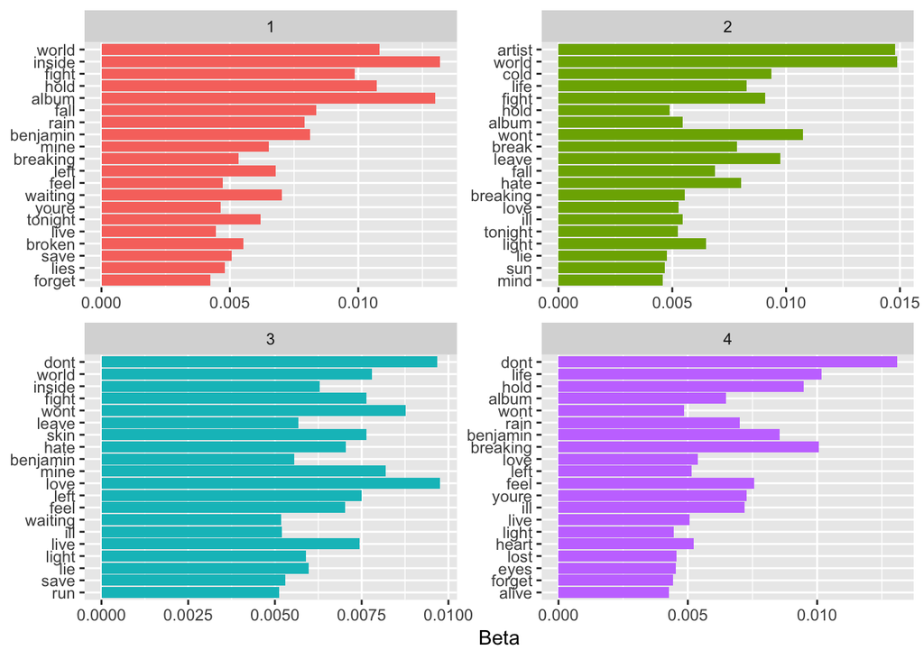

```r
#Lets also look at what Breaking Benjamin is all about:
breakingBenjaminTopics <- top_terms_by_topic_LDA(lyricsdb %>% filter(artist == "Breaking Benjamin") %>% select(lyrics), 4)
plot_top_terms(breakingBenjaminTopics)
```

Usually the 4 topics that we get are supposed to be talking about 4 completely different things, even though we get a similar theme of topics here, that may be because most songs by a particular artist are similar to each other anyway.

## TFIDF:

Now let us try to match the description of a song with one of the songs from our database.

### Defining our Functions for extracting TFIDF:

Lets define a couple of functions, The following function (topTermsTfidf) takes a data frame, along with a columnn name where the text exists(lyrics in our case) and a column name for group, can be link to have a primary key-sort of column.

```r
topTermsTfidf <- function(textdf, textColumn, groupColumn) {
  textColumn <- enquo(textColumn)
  groupColumn <- enquo(groupColumn)


  # get the count of each word in each attack pattern
  countOfWords <- textdf %>%
    unnest_tokens(word, !!textColumn) %>%
    count(!!groupColumn, word) %>%
    ungroup()

  # number of words per text:
  numberOfWords <- countOfWords %>%
    group_by(!!groupColumn) %>%
    summarize(total = sum(n))

  #combine the two dataframes
  words <- left_join(countOfWords, numberOfWords)


  #try to clean the words, remove stopwords:
  words <- words %>%
    filter(!word %in% stop_words$word) %>%
    filter(!word %in% customStopWords)

  #get tfidf and order of words by degree of relevance:

  return(tfidf <- words %>%
    bind_tf_idf(word, !!groupColumn, n) %>%
    select(-total) %>%
    arrange(desc(tf_idf)) %>%
    mutate(word = wordStem(word)) %>%
    group_by(!!groupColumn, word) %>%
    filter(tf_idf == max(tf_idf)) %>%
    ungroup() %>%
    mutate(word = factor(word, levels=rev(unique(word))))
    )
    #filter(unique(list(!!groupColumn, word)))

}


tfidfTable <- topTermsTfidf(lyricsdb, lyrics, fullpath)
tfidfTable = merge(x = select(tfidfTable, fullpath, word, tf_idf), y=lyricsdb, by="fullpath", all=TRUE)

#Example for Sing
tfidfTable %>%
  filter(song == "Sing") %>%
  arrange(-tf_idf) %>%
  head(10)
```

|  | fullpath | word | tf_idf | song | artist | album | lyrics |
| --- | --- | --- | --- | --- | --- | --- | --- |
| 1 | ./lyricsdb/E/Ed Sheeran/x/Sing | tone | 0.14168867 | Sing | Ed Sheeran | x | Its late in the evening Glass on the side Ive been sat with you For most of the night Ignoring everybody here We wish they would disappear So maybe we could get down now I dont wanna know If youre get… |
| 2 | ./lyricsdb/E/Ed Sheeran/x/Sing | sing | 0.13541817 | Sing | Ed Sheeran | x | Its late in the evening Glass on the side Ive been sat with you For most of the night Ignoring everybody here We wish they would disappear So maybe we could get down now I dont wanna know If youre get… |
| 3 | ./lyricsdb/E/Ed Sheeran/x/Sing | darl | 0.13318592 | Sing | Ed Sheeran | x | Its late in the evening Glass on the side Ive been sat with you For most of the night Ignoring everybody here We wish they would disappear So maybe we could get down now I dont wanna know If youre get… |
| 4 | ./lyricsdb/E/Ed Sheeran/x/Sing | involv | 0.13097205 | Sing | Ed Sheeran | x | Its late in the evening Glass on the side Ive been sat with you For most of the night Ignoring everybody here We wish they would disappear So maybe we could get down now I dont wanna know If youre get… |
| 5 | ./lyricsdb/E/Ed Sheeran/x/Sing | feel | 0.12179560 | Sing | Ed Sheeran | x | Its late in the evening Glass on the side Ive been sat with you For most of the night Ignoring everybody here We wish they would disappear So maybe we could get down now I dont wanna know If youre get… |
| 6 | ./lyricsdb/E/Ed Sheeran/x/Sing | rush | 0.12111184 | Sing | Ed Sheeran | x | Its late in the evening Glass on the side Ive been sat with you For most of the night Ignoring everybody here We wish they would disappear So maybe we could get down now I dont wanna know If youre get… |
| 7 | ./lyricsdb/E/Ed Sheeran/x/Sing | toe | 0.11443099 | Sing | Ed Sheeran | x | Its late in the evening Glass on the side Ive been sat with you For most of the night Ignoring everybody here We wish they would disappear So maybe we could get down now I dont wanna know If youre get… |
| 8 | ./lyricsdb/E/Ed Sheeran/x/Sing | louder | 0.08476475 | Sing | Ed Sheeran | x | Its late in the evening Glass on the side Ive been sat with you For most of the night Ignoring everybody here We wish they would disappear So maybe we could get down now I dont wanna know If youre get… |
| 9 | ./lyricsdb/E/Ed Sheeran/x/Sing | ladi | 0.07909391 | Sing | Ed Sheeran | x | Its late in the evening Glass on the side Ive been sat with you For most of the night Ignoring everybody here We wish they would disappear So maybe we could get down now I dont wanna know If youre get… |
| 10 | ./lyricsdb/E/Ed Sheeran/x/Sing | fall | 0.06942261 | Sing | Ed Sheeran | x | Its late in the evening Glass on the side Ive been sat with you For most of the night Ignoring everybody here We wish they would disappear So maybe we could get down now I dont wanna know If youre get… |

The above table shows some words for a particular song (*Sing by Ed Sheeran*). The important columns for us are word and tf_idf.

### Provide Textual description of the song that you want to search here:

This is the textual description for the song that you want to look up:

```r
searchThisSong <- "Protest song  Theme was violence  about people fighting with bombs and guns"
#Thinking about zombie by cranberries
```

Process the above text so we have a set of tokens ready (similar to what the function generates, but since this is only a single document, we can just count the term frequency, which will mostly be 1).

```r
searchSongDB <- data.frame(word = as.character(searchThisSong))
searchSongDB$word = toString(searchSongDB$word)

searchTokens <- unnest_tokens(searchSongDB, tokens, word)
searchTokens = searchTokens %>%
  group_by(tokens) %>%
  summarise(tfidf = n())

searchTokens$tokens = wordStem(searchTokens$tokens)
searchTokens =unique(searchTokens)

head(searchTokens)
```

| tokens | tfidf |
| --- | --- |
| about | 1 |
| and | 1 |
| bomb | 1 |
| fight | 1 |
| gun | 1 |
| peopl | 1 |

## Generating Vocab table:

We need to generate a sparse vocabulary table in order to compare two columns. The vocab table will have one column with all the words from all song lyrics, and also our search terms. It will then have one column for every song and also a column for our search keywords.

```r
vocab = tfidfTable$word
vocab = append(searchTokens$tokens, as.character(vocab))
vocab = unique(vocab)
vocab = data.frame(word = vocab) # make a data frame
vocab = data.table::setorder(vocab, word)#arranging in ascending order of words

#Add a column for system's model:
vocab = merge(x = vocab, y=select(searchTokens, word = tokens, searchTerms = tfidf), by="word", all = TRUE)
vocab = vocab %>%
  group_by(word) %>%
  summarise(searchTerms = max(searchTerms))

for(i in 1:nrow(lyricsdb)) {
  songName = toString(lyricsdb$fullpath[i])
  songTokens = tfidfTable %>%
    filter(fullpath == lyricsdb$fullpath[i]) %>%
    select(word, !!songName := tf_idf)
  vocab = merge(x=vocab, y=songTokens, by="word", all=TRUE)
  #vocab = vocab %>% rename(song = tf_idf)
}

write.csv(vocab, "Vocab.csv")
head(vocab)
```

|  | word | searchTerms | ./lyricsdb/3/3 Doors Down/The Better Life/Kryptonite | ./lyricsdb/A/A Day To Remember/Common Courtesy/Best Of Me | ./lyricsdb/A/A Day To Remember/Common Courtesy/City Of Ocala | ./lyricsdb/A/A Day To Remember/Common Courtesy/Dead & Buried | ./lyricsdb/A/A Day To Remember/Common Courtesy/End Of Me | ./lyricsdb/A/A Day To Remember/Common Courtesy/Good Things | ./lyricsdb/A/A Day To Remember/Common Courtesy/I Remember | ./lyricsdb/A/A Day To Remember/Common Courtesy/I Surrender | ./lyricsdb/A/A Day To Remember/Common Courtesy/I'm Already Gone | ./lyricsdb/A/A Day To Remember/Common Courtesy/Leave All The Lights On | ./lyricsdb/A/A Day To Remember/Common Courtesy/Life @ 11 | ./lyricsdb/A/A Day To Remember/Common Courtesy/Life Lessons Learned The Hard Way | ./lyricsdb/A/A Day To Remember/Common Courtesy/Right Back At It Again | ./lyricsdb/A/A Day To Remember/Common Courtesy/Same Book But Never The Same Page | ./lyricsdb/A/A Day To Remember/Common Courtesy/Sometimes You're The Hammer, Sometimes You're The Nail | ./lyricsdb/A/A Day To Remember/Common Courtesy/The Document Speaks For Itself | ./lyricsdb/A/A Day To Remember/Common Courtesy/Violence (Enough Is Enough) | ./lyricsdb/A/A Flock of Seagulls/A Flock of Seagulls/I Ran (So Far Away) | ./lyricsdb/A/A Perfect Circle/Emotive/Passive | ./lyricsdb/A/A Perfect Circle/Mer de Noms/Magdalena | ./lyricsdb/A/A Perfect Circle/Mer de Noms/Orestes | ./lyricsdb/A/A Perfect Circle/Mer de Noms/The Hollow | ./lyricsdb/A/A Perfect Circle/Thirteenth Step/Weak and Powerless | ./lyricsdb/A/A Split-Second/…From the Inside/Choke | ./lyricsdb/A/A Split-Second/…From the Inside/Mambo Witch | ./lyricsdb/A/A Split-Second/Ballistic Statues/Rigor Mortis | ./lyricsdb/A/Absinth3/Retropolis/Firewall (feat. Lisa Marie Perkins) | … |
| --- | --- | --- | --- | --- | --- | --- | --- | --- | --- | --- | --- | --- | --- | --- | --- | --- | --- | --- | --- | --- | --- | --- | --- | --- | --- | --- | --- | --- | --- | --- |
| 1 | à | NA | NA | NA | NA | NA | NA | NA | NA | NA | NA | NA | NA | NA | NA | NA | NA | NA | NA | NA | NA | NA | NA | NA | NA | NA | NA | NA | NA | … |
| 2 | aaaaaaaah | NA | NA | NA | NA | NA | NA | NA | NA | NA | NA | NA | NA | NA | NA | NA | NA | NA | NA | NA | NA | NA | NA | NA | NA | NA | NA | NA | NA | … |
| 3 | aaaaaaah | NA | NA | NA | NA | NA | NA | NA | NA | NA | NA | NA | NA | NA | NA | NA | NA | NA | NA | NA | NA | NA | NA | NA | NA | NA | NA | NA | NA | … |
| 4 | aaaaah | NA | NA | NA | NA | NA | NA | NA | NA | NA | NA | NA | NA | NA | NA | NA | NA | NA | NA | NA | NA | NA | NA | NA | NA | NA | NA | NA | NA | … |
| 5 | aaaah | NA | NA | NA | NA | NA | NA | NA | NA | NA | NA | NA | NA | NA | NA | NA | NA | NA | NA | NA | NA | NA | NA | NA | NA | NA | NA | NA | NA | … |
| 6 | aaah | NA | NA | NA | NA | NA | NA | NA | NA | NA | NA | NA | NA | NA | NA | NA | NA | NA | NA | NA | NA | NA | NA | NA | NA | NA | NA | NA | NA | … |

We can then use the vocab table to calculate the KL distances between search column and every other song, we show the top 10 songs with the least distance (and hopefully the first one is the song you were thinking about!):

```r
vocab2 = vocab

checkDistance <- function(A, B) {
  return(kl.dist(A,B)$D1)
}


allSongs = lyricsdb %>%
  group_by(fullpath) %>%
  summarise(n=n())

distances = rep(0, length(allSongs$fullpath))

vocab2 = vocab2 %>% replace(is.na(.), 0)

i=1
for(entry in allSongs$fullpath) {
  distance = 999
  distance = checkDistance(vocab2$searchTerms, vocab2[[entry]])
  distances[i] = distance
  i=i+1
}
lyricsdb$distance = distances

lyricsdb %>%
  arrange(distances) %>%
  head(10)
```

|  | fullpath | song | artist | album | lyrics | distance |
| --- | --- | --- | --- | --- | --- | --- |
| 1 | ./lyricsdb/T/The Cranberries/No Need To Argue (The Complete Sessions 1994-1995)/Zombie | Zombie | The Cranberries | No Need To Argue (The Complete Sessions 1994-1995) | Another head hangs lowly Child is slowly taken And the violence caused such silence Who are we mistaken But you see its not me Its not my family In your head in your head They are fighting With their … | 13.71934 |
| 2 | ./lyricsdb/E/Eminem/The Marshall Mathers LP 2/Rap God | Rap God | Eminem | The Marshall Mathers LP 2 | Look I was gonna go easy on you not to hurt your feelings But Im only going to get this one chance Somethings wrong I can feel it Six minutes Slim Shady youre on Just a feeling Ive got like somethings… | 15.04036 |
| 3 | ./lyricsdb/T/The Clash/London Calling/Spanish Bombs | Spanish Bombs | The Clash | London Calling | Spanish songs in Andalucia The shooting sites in the days of Oh please leave the vendanna open Federico Lorca is dead and gone Bullet holes in the cemetery walls The black cars of Guardia Civil Spanis… | 15.88368 |
| 4 | ./lyricsdb/S/Snoop Lion/Reincarnated/No Guns Allowed | No Guns Allowed | Snoop Lion | Reincarnated | Money makes a man and thats a crime If we all were rich wed spend more time With our daughters and sons theyre loosing their minds We all feel hurt heres mine here me now Cause no guns are allowed in … | 16.64406 |
| 5 | ./lyricsdb/A/A Day To Remember/Common Courtesy/Violence (Enough Is Enough) | Violence (Enough Is Enough) | A Day To Remember | Common Courtesy | Ive been feeling like everything is for nothing In fact Ive never felt so goddamn small Always searching for the bright side to find the strength for when I fall Im still believing that life has a mea… | 16.68546 |
| 6 | ./lyricsdb/A/Atari Teenage Riot/Reset/New Blood | New Blood | Atari Teenage Riot | Reset | Stuck by the news its hard to hear a fucking sound Theyre kicking down the doors and taking everyone down And I know for sure that I cant trust you anymore A history in violence and theyre coming for … | 16.76216 |
| 7 | ./lyricsdb/S/Slipknot/Antennas To Hell/People = Shit | People = Shit | Slipknot | Antennas To Hell | Come on Here we go again motherfucker Yeah Come on down and see the idiot right here Too fucked to beg and not afraid to care Whats the matter with calamity anyway Right Get the fuck outta my face Und… | 16.76304 |
| 8 | ./lyricsdb/T/Twenty One Pilots/Blurryface/Fairly Local | Fairly Local | Twenty One Pilots | Blurryface | Im fairly local Ive been around Ive seen the streets youre walking down Im fairly local good people now Oh oh oh oh oh oh oh Im evil to the core What I shouldnt do I will They say Im emotional What I … | 16.87932 |
| 9 | ./lyricsdb/T/The Killing Tree/The Romance of Helen Trent/Counting to Infinity | Counting to Infinity | The Killing Tree | The Romance of Helen Trent | Ive seen nations Ive seen empires rise and fall in your eyes just enough to come crawling back to you but not enought to turn the tide the song she sings infects my ears the dances she dances fills my… | 17.02025 |
| 10 | ./lyricsdb/C/Cypress Hill/Stoned Raiders/Memories | Memories | Cypress Hill | Stoned Raiders | As I sit in my silver stack thinking about way back Even before I started blazing the chronic sack I was a go wild unfocused troublesome kid Looking up to all the gangsters and the shit they did I was… | 17.10356 |

# Resources and Disclaimers:

- Primary resource that this document is based on: https://www.kaggle.com/rtatman/nlp-in-r-topic-modelling
- Theoretical concepts from: https://arxiv.org/pdf/1711.04305.pdf
- This document is also vaguely similar to what I did for an independent study project with prof. Fleming, the approach is the same but the data sets (And the relevant changes) is very different. The document structure is also very different since that was a project report and not a guide. I would like to confirm that I have written this document from scratch for this project.
- The approach is also inspired from the concepts that I learnt in another course DS 5559: Exploratory Text Analytics. My final project in that course is also on topic modeling, but the course and all relevant work was done in Python.